# Chapter 1 - Statistical preliminaries: computer exercises

**Solution**

Some possible approaches:

```r
iris[iris$Petal.Length>5,]
```

```
    Sepal.Length Sepal.Width Petal.Length Petal.Width    Species
84           6.0         2.7          5.1         1.6 versicolor
101          6.3         3.3          6.0         2.5  virginica
102          5.8         2.7          5.1         1.9  virginica
103          7.1         3.0          5.9         2.1  virginica
104          6.3         2.9          5.6         1.8  virginica
105          6.5         3.0          5.8         2.2  virginica
106          7.6         3.0          6.6         2.1  virginica
108          7.3         2.9          6.3         1.8  virginica
109          6.7         2.5          5.8         1.8  virginica
110          7.2         3.6          6.1         2.5  virginica
111          6.5         3.2          5.1         2.0  virginica
112          6.4         2.7          5.3         1.9  virginica
113          6.8         3.0          5.5         2.1  virginica
115          5.8         2.8          5.1         2.4  virginica
```

[output cut: 28 more lines]

```r
summary(iris[iris$Petal.Length>5,'Species'])/dim(iris[iris$Petal.Length>5,])[1]
```

```
    setosa versicolor  virginica
0.00000000 0.02380952 0.97619048
```

```r
iris |>
  filter(Petal.Length > 5)
```

```
   Sepal.Length Sepal.Width Petal.Length Petal.Width    Species
1           6.0         2.7          5.1         1.6 versicolor
2           6.3         3.3          6.0         2.5  virginica
3           5.8         2.7          5.1         1.9  virginica
4           7.1         3.0          5.9         2.1  virginica
5           6.3         2.9          5.6         1.8  virginica
6           6.5         3.0          5.8         2.2  virginica
7           7.6         3.0          6.6         2.1  virginica
8           7.3         2.9          6.3         1.8  virginica
9           6.7         2.5          5.8         1.8  virginica
10          7.2         3.6          6.1         2.5  virginica
11          6.5         3.2          5.1         2.0  virginica
12          6.4         2.7          5.3         1.9  virginica
13          6.8         3.0          5.5         2.1  virginica
14          5.8         2.8          5.1         2.4  virginica
```

[output cut: 28 more lines]

```r
# Lots of ways to do this.
iris |>
  filter(Petal.Length > 5)|>
  group_by(Species) |>
  summarise(n = n()) |>
  mutate(freq = n / sum(n))
```

```
# A tibble: 2 × 3
  Species        n   freq
  <fct>      <int>  <dbl>
1 versicolor     1 0.0238
2 virginica     41 0.976
```

```r
iris |>
  filter(Petal.Length > 5) |>
  count(Species) |>
  mutate(freq = n / sum(n))
```

```
     Species  n       freq
1 versicolor  1 0.02380952
2  virginica 41 0.97619048
```

A nice aspect of dplyr is that you can chain commmands together. So for example, to select the versicolour flowers with petal width less than 1.5, we can do

```r
iris |> filter(Species=='versicolor') |> filter(Petal.Width<1.5)
```

- Can you select all the flowers that have a sepal length greater than 6, and a petal length less than 5? What is the proportion of each species in this set?

**Solution**

```r
iris[iris$Sepal.Length>6& iris$Petal.Length<5,]
```

```
    Sepal.Length Sepal.Width Petal.Length Petal.Width    Species
51           7.0         3.2          4.7         1.4 versicolor
52           6.4         3.2          4.5         1.5 versicolor
53           6.9         3.1          4.9         1.5 versicolor
55           6.5         2.8          4.6         1.5 versicolor
57           6.3         3.3          4.7         1.6 versicolor
59           6.6         2.9          4.6         1.3 versicolor
64           6.1         2.9          4.7         1.4 versicolor
66           6.7         3.1          4.4         1.4 versicolor
69           6.2         2.2          4.5         1.5 versicolor
72           6.1         2.8          4.0         1.3 versicolor
73           6.3         2.5          4.9         1.5 versicolor
74           6.1         2.8          4.7         1.2 versicolor
75           6.4         2.9          4.3         1.3 versicolor
76           6.6         3.0          4.4         1.4 versicolor
77           6.8         2.8          4.8         1.4 versicolor
87           6.7         3.1          4.7         1.5 versicolor
88           6.3         2.3          4.4         1.3 versicolor
92           6.1         3.0          4.6         1.4 versicolor
98           6.2         2.9          4.3         1.3 versicolor
124          6.3         2.7          4.9         1.8  virginica
127          6.2         2.8          4.8         1.8  virginica
128          6.1         3.0          4.9         1.8  virginica
```

```r
summary(iris[iris$Sepal.Length>6& iris$Petal.Length<5,'Species'])/dim(iris[iris$Sepal.Length>6& iris$Petal.Length<5,])[1]
```

```
    setosa versicolor  virginica
 0.0000000  0.8636364  0.1363636
```

```r
# with dplyr
iris |> filter(Sepal.Length>6, Petal.Length<5) |>
  count(Species) |>
  mutate(freq =n/sum(n))
```

```
     Species  n      freq
1 versicolor 19 0.8636364
2  virginica  3 0.1363636
```

Note that `iris` is a data frame

```r
is.data.frame(iris)
```

```
[1] TRUE
```

which is a type of structure used in R. This is convenient for some tasks, but not for others. Let’s first extract the four numerical columns and store them as a matrix $X$.

```r
is.matrix(iris)
```

```
[1] FALSE
```

```r
X <- as.matrix(iris[,1:4])
is.matrix(X)
```

```
[1] TRUE
```

- Select the 4 numerical columns and multiply the first column by 1, the second by 2, the third by 3, and the 4th by 4. One way to do this is by multiplying $X$ by the diagonal matrix

```r
diag(1:4)
```

```
     [,1] [,2] [,3] [,4]
[1,]    1    0    0    0
[2,]    0    2    0    0
[3,]    0    0    3    0
[4,]    0    0    0    4
```

**Solution**

```r
# ---------------------
# Data frame vs matrix is an annoyance we have to deal with.

as.matrix(iris[,1:4]) %*% diag(1:4)
```

```
       [,1] [,2] [,3] [,4]
  [1,]  5.1  7.0  4.2  0.8
  [2,]  4.9  6.0  4.2  0.8
  [3,]  4.7  6.4  3.9  0.8
  [4,]  4.6  6.2  4.5  0.8
  [5,]  5.0  7.2  4.2  0.8
  [6,]  5.4  7.8  5.1  1.6
  [7,]  4.6  6.8  4.2  1.2
  [8,]  5.0  6.8  4.5  0.8
  [9,]  4.4  5.8  4.2  0.8
 [10,]  4.9  6.2  4.5  0.4
 [11,]  5.4  7.4  4.5  0.8
 [12,]  4.8  6.8  4.8  0.8
 [13,]  4.8  6.0  4.2  0.4
 [14,]  4.3  6.0  3.3  0.4
```

[output cut: 136 more lines]

### Task 2

The table below shows the module marks for 5 students on the modules G11PRB ($P$) and G11STA ($S$).

| Student | P | S |
| --- | --- | --- |
| A | 41 | 63 |
| B | 72 | 82 |
| C | 46 | 38 |
| D | 77 | 57 |
| E | 59 | 85 |

- As an exercise, calculate the sample mean, sample covariance and sample correlation by hand.

**Solution**

The sample mean is $\bar{\mathbf x} = \begin{pmatrix} 59 \\ 65 \end{pmatrix}$.

The sample covariance matrix is $\mathbf S= \begin{pmatrix} 197.2 & 92.8 \\ 92.8 & 297.2 \end{pmatrix}$.

The sample correlation matrix is
$$\begin{align*}
\mathbf R&= \mathbf D^{-1} \mathbf S\mathbf D^{-1}\\
&= \begin{pmatrix} 14.0 & 0 \\ 0 & 17.2 \end{pmatrix}^{-1} \begin{pmatrix} 197.2 & 92.8 \\ 92.8 & 297.2 \end{pmatrix} \begin{pmatrix} 14.0 & 0 \\ 0 & 17.2 \end{pmatrix}^{-1} \\
&= \begin{pmatrix} 0.071 & 0 \\ 0 & 0.058 \end{pmatrix} \begin{pmatrix} 197.2 & 92.8 \\ 92.8 & 297.2 \end{pmatrix} \begin{pmatrix} 0.071 & 0 \\ 0 & 0.058 \end{pmatrix} \\
&= \begin{pmatrix} 1.000 & 0.383 \\ 0.383 & 1.000 \end{pmatrix}.
\end{align*}$$

- Now calculate these in R using `colMeans`, `cov`, and `cor`. These commands assume each column is a different variable, and each row a different observation. **Note that** by default R uses $n-1$ in the denominator for the variance and covariance commands, whereas we used $n$ in our definition.

**Solution**

```r
library(dplyr)
Ex1 <- data.frame(
  Student=LETTERS[1:5],
  P = c(41,72,46,77,59),
  S = c(63,82,38,57,85)
  )

Ex1 |> select_if(is.numeric) |> colMeans()
```

```
 P  S
59 65
```

```r
Ex1 |> select_if(is.numeric) |> cov()
```

```
      P     S
P 246.5 116.0
S 116.0 371.5
```

```r
Ex1 |> select_if(is.numeric) |> cor()
```

```
          P         S
P 1.0000000 0.3833276
S 0.3833276 1.0000000
```

```r
# or if we use 1/n as the denominator for the covariance matrix
Ex1 |> select_if(is.numeric) |> cov()*4/5
```

```
      P     S
P 197.2  92.8
S  92.8 297.2
```

You could compute the same quantities using more familiar commands by selecting the numerical columns:

```r
colMeans(Ex1[,2:3])
```

```
 P  S
59 65
```

```r
cov(Ex1[,2:3])
```

```
      P     S
P 246.5 116.0
S 116.0 371.5
```

- Can you compute the covariance matrix using the definition in Equation 1.2?

**Solution**

```r
mu=Ex1 |> select_if(is.numeric) |> colMeans()
X<- as.matrix(Ex1[,2:3])
Xcent<- sweep(X, 2, mu) #remove column means
t(Xcent)%*%Xcent/4
```

```
      P     S
P 246.5 116.0
S 116.0 371.5
```

### Task 3

The `mtcars` dataset is another built-in dataset in R. You can read about it by typing `?mtcars` in R. Note that some of the variables are factors. You can ensure R treats them as factors by using the following command to create a dataset where they are listed as factors:

```r
mtcars2 <- within(mtcars, {
   vs <- factor(vs, labels = c("V", "S"))
   am <- factor(am, labels = c("automatic", "manual"))
   cyl  <- ordered(cyl)
   gear <- ordered(gear)
   carb <- ordered(carb)
})
```

Work with the `mtcars2` dataframe when you use `ggplot2`.

- Create some plots to explore the structure of this dataset using ggplot2.

**Solution**

There are many different things we could plot here. Have a play around. Some ideas are below.

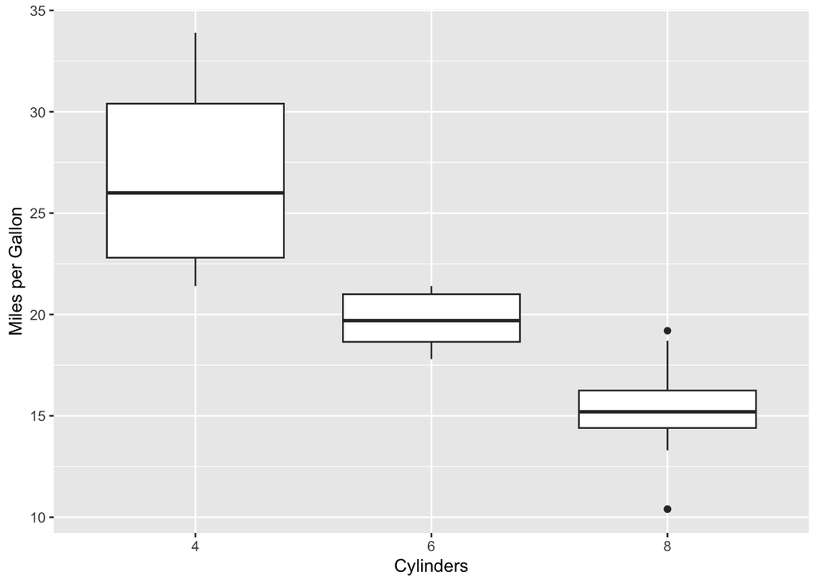

```r
ggplot(mtcars2,aes(x=cyl,y=mpg)) + geom_boxplot() +
  xlab('Cylinders') + ylab('Miles per Gallon')
```

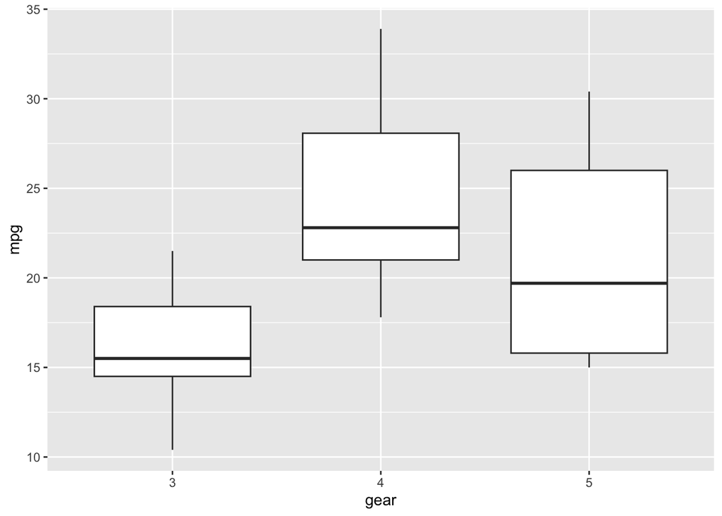

```r
ggplot(data=mtcars2, aes(x=gear, y=mpg))+geom_boxplot()
```

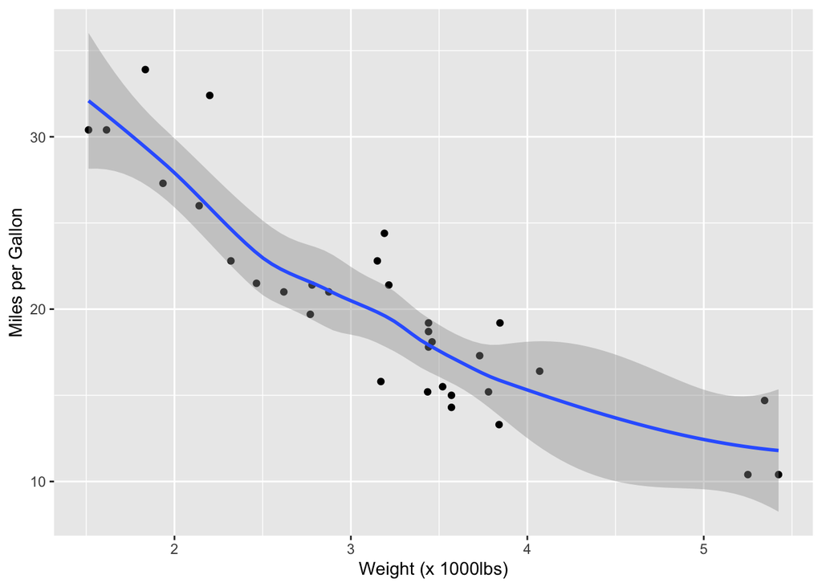

```r
ggplot(mtcars2,aes(x=wt,y=mpg)) + geom_point()+
  xlab('Weight (x 1000lbs)') + ylab('Miles per Gallon') + geom_smooth()
```

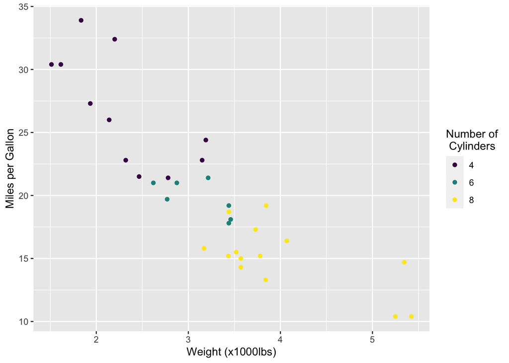

```r
ggplot(mtcars2,aes(x=wt,y=mpg,col=cyl)) + geom_point() +
  labs(x='Weight (x1000lbs)',y='Miles per Gallon',colour='Number of\n Cylinders')
```

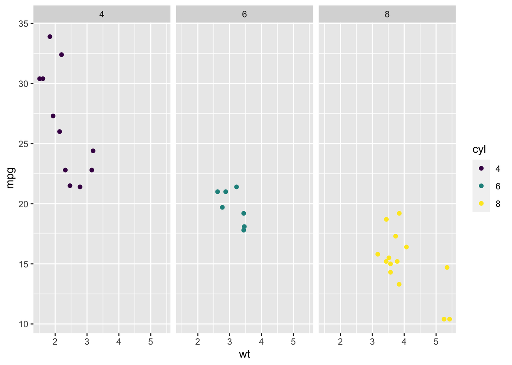

```r
ggplot(mtcars2,aes(x=wt,y=mpg,col=cyl)) + geom_point() +
  facet_grid(~cyl)
```

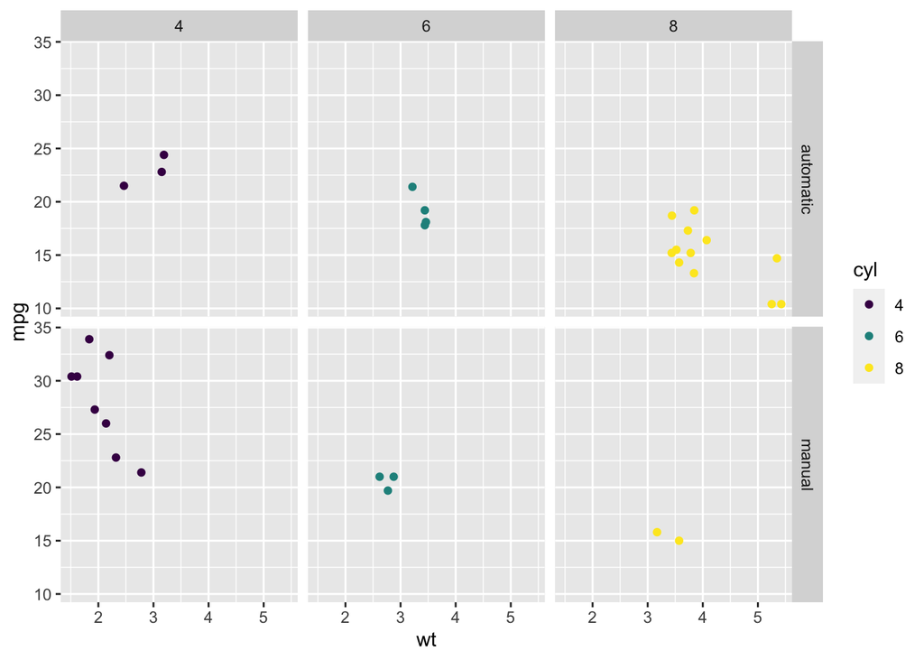

```r
ggplot(mtcars2,aes(x=wt,y=mpg,col=cyl)) + geom_point() + facet_grid(am~cyl)
```

- Try using the `pairs` command from base R and the `ggpairs` command from GGally.

**Solution**

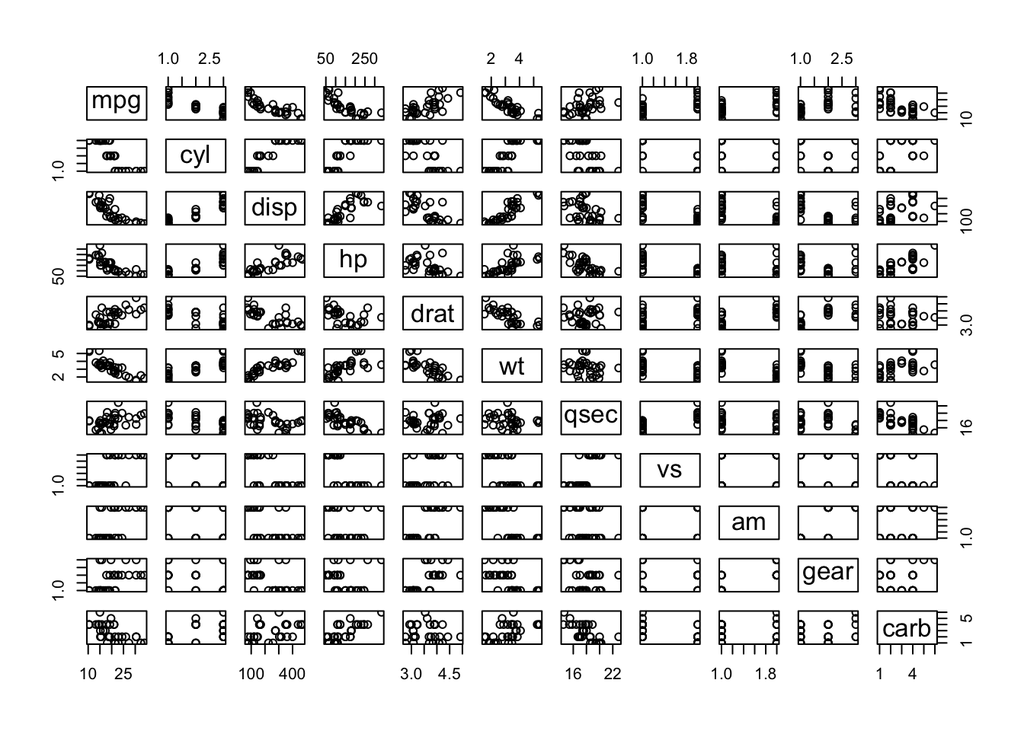

```r
library(ggplot2)
library(GGally)

pairs(mtcars2)
```

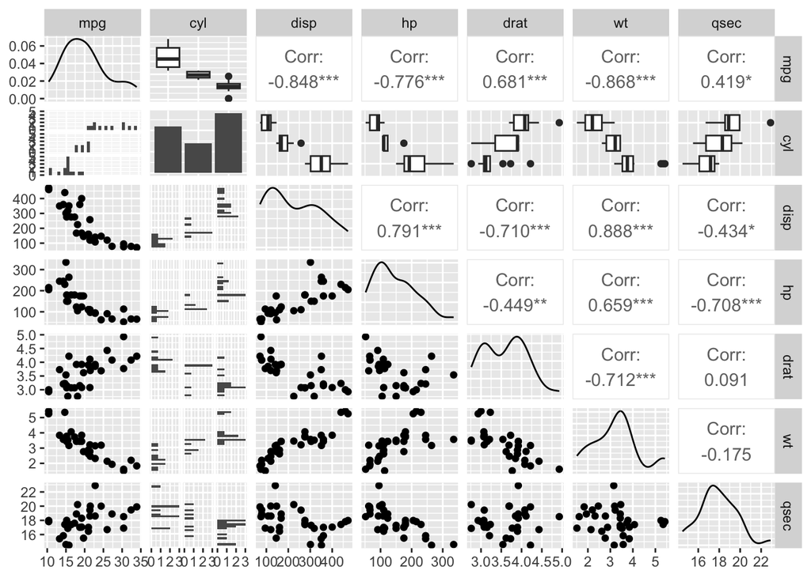

```r
ggpairs(mtcars2,
        columns=c('mpg', 'cyl', 'disp', 'hp', 'drat', 'wt', 'qsec'))
```

- Try colouring the scatter plots accoring to whether the car is automatic or not.

**Solution**

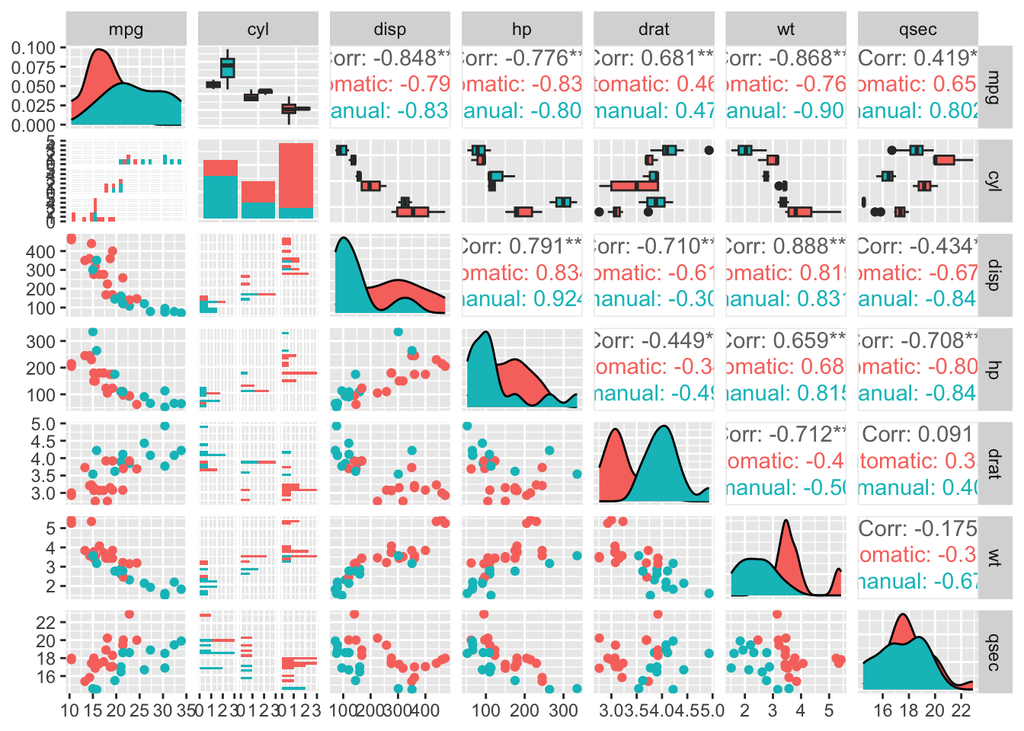

```r
ggpairs(mtcars2,
        columns=c('mpg', 'cyl', 'disp', 'hp', 'drat', 'wt', 'qsec'),
        mapping=ggplot2::aes(colour = am))
```

- Create another plot using colour to represent the number of gears.

**Solution**

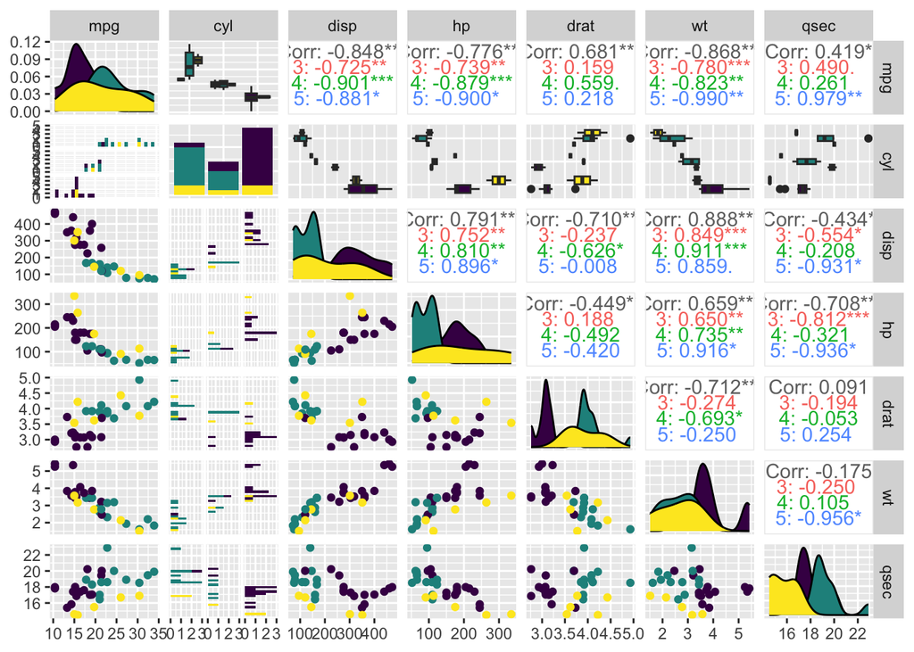

```r
ggpairs(mtcars2, columns=c('mpg', 'cyl', 'disp', 'hp', 'drat', 'wt', 'qsec'),
        mapping=ggplot2::aes(colour = gear))
```

### Task 4

4. We can 100 generate samples from the multivariate normal distribution with mean vector
   $${\boldsymbol{\mu}}= \left(\begin{array}{c}1\\0\end{array}\right)$$
   and covariance matrix
   $$\boldsymbol{\Sigma}= \left(\begin{array}{cc}2&1\\1&2\end{array}\right)$$
   as follows (you may need to install the R package `mvtnorm` first):

```r
library(mvtnorm)
mu = c(1,0)
Sigma=matrix(c(2,1,1,2), nr=2)
X <- rmvnorm(n=100, mean=mu, sigma=Sigma)
```

- Compute the sample mean and covariance matrix of these samples.

**Solution**

```r
colMeans(X)
```

```
[1] 1.141306448 0.005278772
```

```r
cov(X)
```

```
         [,1]     [,2]
[1,] 1.805409 0.962640
[2,] 0.962640 2.494835
```

- Generate a new sample dataset, $X$, and recompute the sample mean and covariance matrix. What do you notice?

**Solution**

This is a random sample, so we will get a different mean and variance estimate every time

```r
X <- rmvnorm(n=100, mean=mu, sigma=Sigma)
colMeans(X)
```

```
[1] 0.92817249 0.02684646
```

```r
cov(X)
```

```
          [,1]      [,2]
[1,] 2.1169347 0.8773716
[2,] 0.8773716 1.4799267
```

But you can set the random number generator seed - then you will get the same set of ‘random’ numbers each time

```r
set.seed(1)
X <- rmvnorm(n=100, mean=mu, sigma=Sigma)
colMeans(X)
```

```
[1] 1.09782528 0.02528767
```

```r
cov(X)
```

```
          [,1]      [,2]
[1,] 1.6917264 0.8782282
[2,] 0.8782282 1.7852600
```

```r
set.seed(1)
X <- rmvnorm(n=100, mean=mu, sigma=Sigma)
colMeans(X)
```

```
[1] 1.09782528 0.02528767
```

```r
cov(X)
```

```
          [,1]      [,2]
[1,] 1.6917264 0.8782282
[2,] 0.8782282 1.7852600
```

- Try changing $n$, the number of samples (making it much larger say), and now recomputing the mean and covariance. What do you notice?

**Solution**

If we use a larger value of $n$, we will get less variable estimates of the mean and variance, and the values will converge towards the true mean and variance.

```r
X <- rmvnorm(n=10000, mean=mu, sigma=Sigma)
colMeans(X)
```

```
[1] 0.981090598 0.003264483
```

```r
cov(X)
```

```
         [,1]     [,2]
[1,] 2.033034 1.006888
[2,] 1.006888 1.984479
```

### Task 5

5. **Optional** Download the MNIST data from Moodle and load it into R.

```r
load('mnist.rda')
```

This loads a list `mnist` that splits the data into two parts

```r
mnist$train ## a training set of 60000 images
mnist$test ## a test set of 10000 images
```

Let’s just look at the training set. This is also a list containing the image intensities and the image labels

```r
mnist$train$x # image intensities
mnist$train$y # image labels
```

If we select just the first image we can see it is a vector of length 784 containing numbers between 0 and 1.

```r
mnist$train$x[1,]
```

I’ve created a function to help you plot these images.

```r
library(reshape2)
library(ggplot2)


plot.mnist <- function(im){
  #im[im<0]<-0 # set any negative intensities to zero
  #im[im>1]<-1 # set an intensities bigger than 1 to 1.


  if(is.vector(im)){ # a single image

    A<-matrix(im, nr=28, byrow=F)
    C<- melt(A, varnames = c("x", "y"),
             value.name = "intensity")
    p<-ggplot(C, aes(x = x, y = y, fill = intensity))+
      geom_tile(aes(fill=intensity))+
      scale_fill_gradient(low='white', high='black')+
      scale_y_reverse()+theme(
        strip.background = element_blank(),
        strip.text.x = element_blank(),
        panel.spacing = unit(0, "lines"),
        axis.text = element_blank(),
        axis.ticks = element_blank()
      )
  }
  else{
    if (dim(im)[2]!=784){
      im = t(im)
    }
    n <- dim(im)[1]
    As <- array(im, dim = c(n, 28, 28))

    Cs<- melt(As, varnames = c("image","x", "y"),
              value.name = "intensity")
    p<-ggplot(Cs, aes(x = x, y = y, fill = intensity))+
      geom_tile(aes(fill=intensity))+
      scale_fill_gradient(low='white', high='black')+
      facet_wrap(~ image, nrow = floor(sqrt(n))+1,
                 ncol = floor(sqrt(n))+1)+
      scale_y_reverse()+theme(
        strip.background = element_blank(),
        strip.text.x = element_blank(),
        panel.spacing = unit(0, "lines"),
        axis.text = element_blank(),
        axis.ticks = element_blank()
      )

  }
  return(p)
}
```

- Use this command to plot the first 10 images from the MNIST training set.

**Solution**

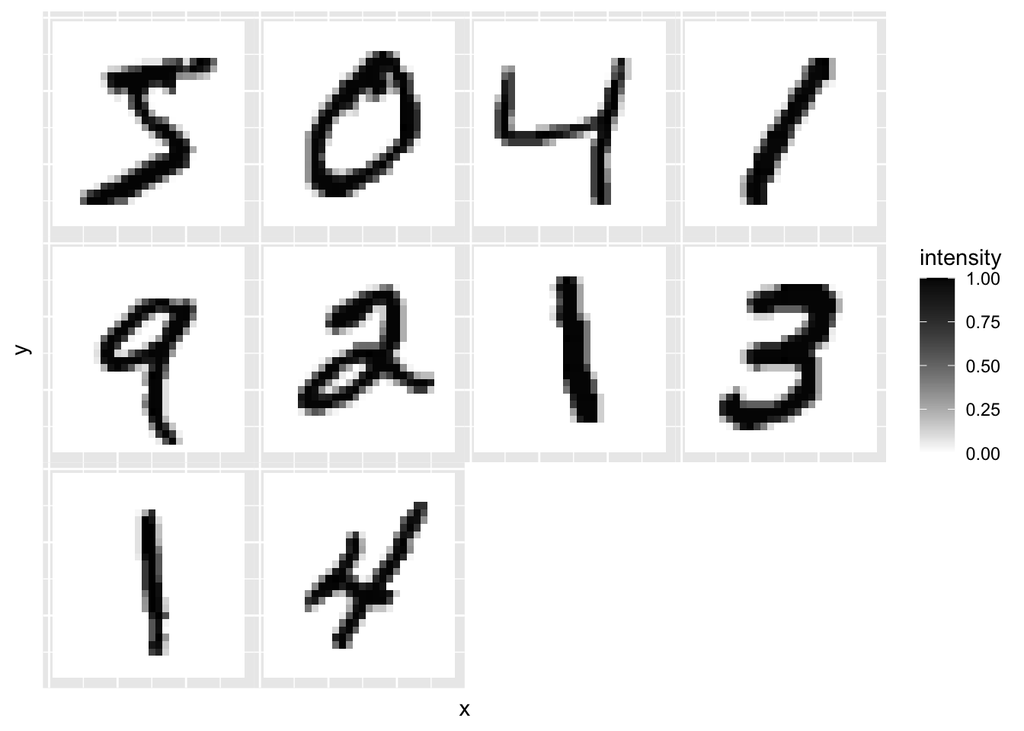

```r
plot.mnist(mnist$train$x[1:10,])
```

- Select all the 5s from the MNIST training set. Plot a selection of these digits.

**Solution**

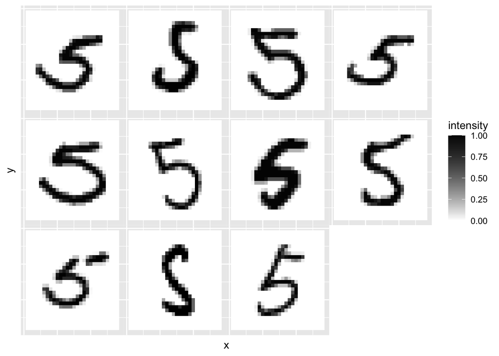

```r
mnist5 <- mnist$train$x[mnist$train$y==5,]

plot.mnist(mnist5[20:30,])
```